## **Practical 2: Github & Rstudio for collaborative coding**

### **Welcome to the evolutionary lottery of skull and beak morphology**

### **#EvoLottery**

#### **Beak and skull shapes in birds of prey (“raptors”) are strongly coupled and largely controlled by size.**

- In this exercise, each participant will **fork a github repo**, and **contribute a file** required to simulate the *evolutionary trajectory of an imaginary species’ body size*.
- We’ll use **github to collate all species files** and **plot** them all up together at the end! We’ll also **discover the skull and beak shapes** associated with each simulated species size.

[handy github glossary](https://help.github.com/enterprise/11.10.340/user/articles/github-glossary/)

# GO!

## **github: start with a repo**

https://github.com/RSE-Sheffield/collaborative_github_exercise

[figure not shown]

## **fork repo**

**github: make your** own copy of the repository** on github

- fork are linked and traceable

[figure not shown]

**github:** Github makes a **copy into your account**

[figure not shown]

**github: clone it: copy repo link** to initiate Rstudio project

[figure not shown]

## **create new project in Rstudio**

**rstudio:** Create **new project**

[figure not shown]

**rstudio:** Checkout from **version control repository**

[figure not shown]

**rstudio:** Clone project from a **git** repository

[figure not shown]

**rstudio:** Paste **repo link copied from Github** into **Repository URL** field. Click **`Create Project`**.

[figure not shown]

**rstudio:** Rstudio project now **contains all files from the github repo.**

[figure not shown]

## **make a change to the repo**

**rstudio:** open **`params/params_tmpl.R`**

[figure not shown]

**rstudio:** **save as new** `.R` script in **`params/`** folder. Use species name of your choice to name new file. Please to not overwrite file **`params/params_tmpl.R`**.

[figure not shown]

**rstudio:** edit file with parameters of your choice and save.

[figure not shown]

The parameters each participants need to supply are:

- **`sig2`:** A numeric value greater than 0 but smaller than 5
- **`species.name`:** a character string e.g. `"anas_krystallinus"`. Try to create a species name out of your name!
- **`color`:** a character string e.g. `"red"`, `"#FFFFFF"` (tip: **pick a color using Rstudio’s Color picker:**)

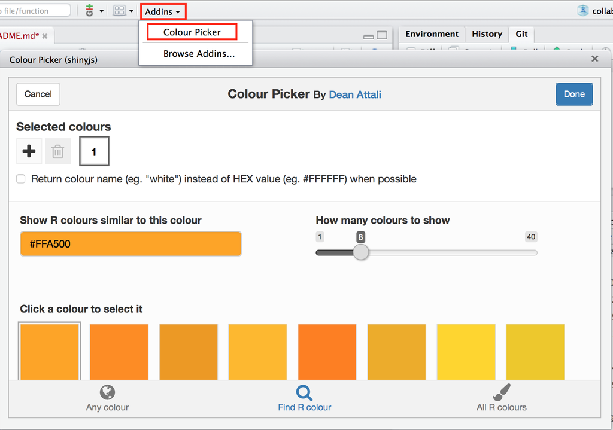

## commit changes locally to git

**rstudio:** in the *git* tab, select the **new file** you created and click **`Commit`**

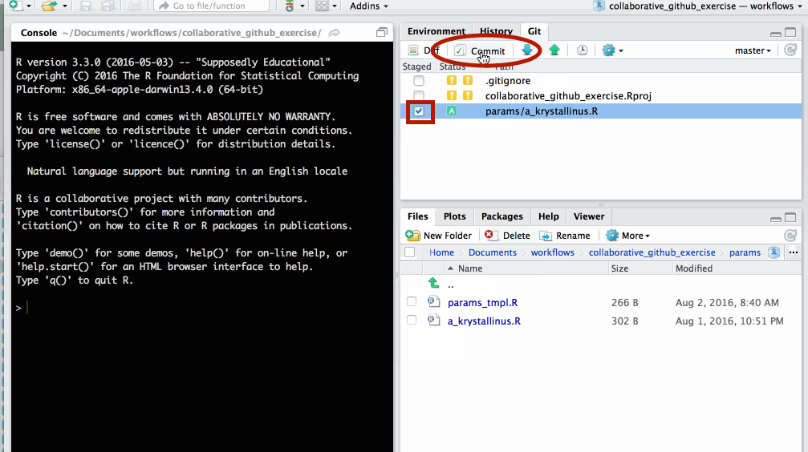

**rstudio:** write an informative commit message and click **`Commit`**

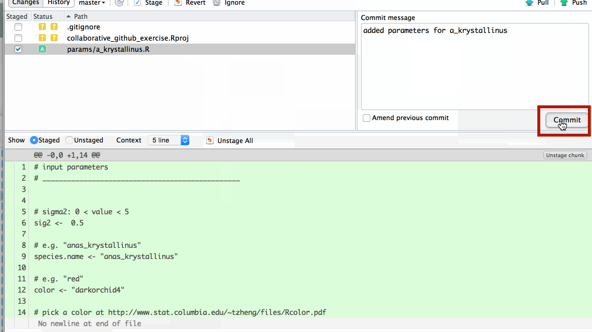

**rstudio:** your new file has now been commited

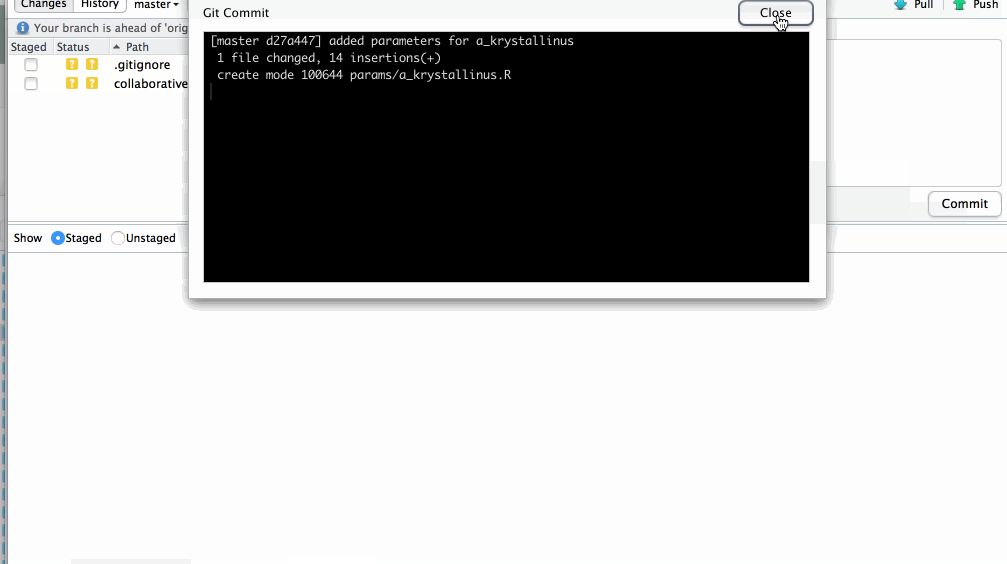

## push changes to Github

**rstudio:** on the *git* tab click ⇧ to **push changes to Github**

[figure not shown]

**rstudio:** changes have now been updated in the **Github repo**

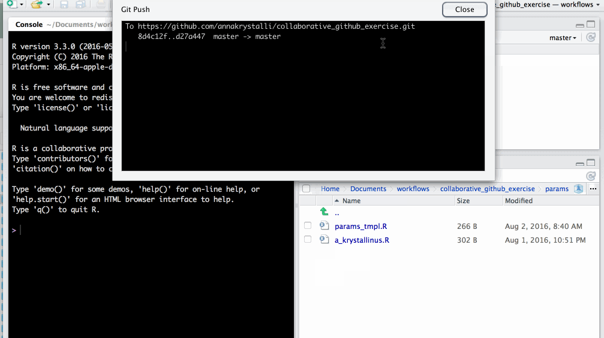

## create pull request

**github:** in your repository, create **`new pull request`** to merge fork to master repo (ie the original repo you forked)

[figure not shown]

**github:** github checks whether your requested merge creates any coflicts. If all is good, click on **`Create pull request`**

[figure not shown]

**github:** write an informative message, explaining your changes to the master repo administrators. Click on **`Create pull request`**

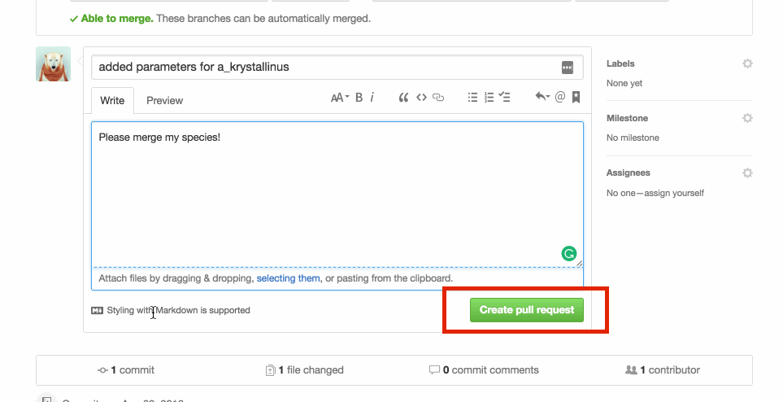

**github:** check original repo to see **your merged changes**

[figure not shown]

# exercise

## your mission

- **fork the repo**: https://github.com/RSE-Sheffield/collaborative_github_exercise
- **link** it up to a **new Rstudio project**.
- **create a new params** `.R` script. Name it using your selected species name.
- **enter parameters** for your species.
- **commit & push** your changes
- **create a pull request** to the master repo

We’ll merge all contributions and [plot them together at the end!](http://rpubs.com/annakrystalli/MozFest_EvoLottery)

## resources

[link to presentation handout](https://github.com/annakrystalli/ISBE_symposium/blob/master/Collaborative_github_test/collab_gh_into.md)

[Karthik Ram’s article:](http://scfbm.biomedcentral.com/articles/10.1186/1751-0473-8-7) *‘Git can facilitate greater reproducibility and increased transparency in science’*

[Getting started with GitHub](http://jennybc.github.io/2014-05-12-ubc/ubc-r/session2.4_github.html) from materials for a [software carpentry course at UBC](http://jennybc.github.io/2014-05-12-ubc/)

[Slides for lecture](http://kbroman.org/Tools4RR/assets/lectures/04_git_withnotes.pdf) Karl Broman gave on git/github, with notes

[joeyklee’s friendly github intro](https://github.com/joeyklee/friendly-github-intro). *Mozilla Science Lab* workshop